# Assignment 2

### 2) Feature Selection

Choose the best **K=9** features

```python
from sklearn.feature_selection import SelectKBest
selector = SelectKBest(k=9)
selector.fit(total_df_normalized_zscore2, Y)
total_df_reduced1 = pd.DataFrame(selector.transform(total_df_normalized_zscore2))
print("Dataset after applying feature selection with the best 9 features")
display(total_df_reduced1)
```

```
Dataset after applying feature selection with the best 9 features
```

|  | 0 | 1 | 2 | 3 | 4 | 5 | 6 | 7 | 8 |
| --- | --- | --- | --- | --- | --- | --- | --- | --- | --- |
| 0 | 0.027539 | -0.808696 | -0.727621 | -0.839220 | -0.841382 | -0.866965 | 0.071789 | -0.870602 | 0.156038 |
| 1 | 0.166738 | -0.796081 | -0.699073 | -0.836667 | -0.832214 | -0.923748 | 0.033306 | -0.855067 | 0.283547 |
| 2 | 0.271138 | -0.810636 | -0.721277 | -0.849433 | -0.841382 | -0.923748 | 0.091031 | -0.875781 | 0.256926 |
| 3 | 0.236338 | -0.817429 | -0.714933 | -0.867306 | -0.847494 | -1.003245 | 0.100651 | -0.870602 | 0.400405 |
| 4 | -0.216061 | -0.812577 | -0.737137 | -0.839220 | -0.844438 | -0.844252 | 0.081410 | -0.868013 | 0.121116 |
| 5 | 0.079739 | -0.825192 | -0.740309 | -0.862199 | -0.853607 | -0.923748 | 0.119893 | -0.886138 | 0.244069 |
| 6 | -0.981659 | -0.446749 | -0.378706 | -0.420492 | -0.538826 | -0.191244 | -0.659387 | -0.448554 | -0.168482 |
| 7 | -0.233461 | -0.501090 | -0.397737 | -0.522621 | -0.569387 | -0.554657 | -0.409248 | -0.552124 | 0.011522 |
| 8 | -0.268261 | -0.507882 | -0.394565 | -0.530281 | -0.584668 | -0.566014 | -0.486214 | -0.559892 | 0.039329 |
| 9 | -0.390060 | -0.412787 | -0.331126 | -0.400066 | -0.502153 | -0.253706 | -0.649766 | -0.427840 | -0.126668 |
| 10 | 0.375538 | -0.867888 | -0.778372 | -0.923476 | -0.878056 | -1.082741 | 0.312307 | -0.922387 | 0.512593 |
| 11 | -1.190458 | -0.356505 | -0.318438 | -0.300491 | -0.456311 | 0.081316 | -0.774836 | -0.326860 | -0.264250 |
| 12 | 0.097138 | -0.804814 | -0.711761 | -0.846880 | -0.835270 | -0.940783 | 0.091031 | -0.860245 | 0.278391 |
| 13 | -0.129061 | -0.402113 | -0.331126 | -0.382194 | -0.489928 | -0.196922 | -0.640145 | -0.409716 | -0.174334 |
| 14 | -1.381858 | -0.479742 | -0.442145 | -0.435811 | -0.563275 | -0.100391 | -0.563180 | -0.464090 | -0.252963 |
| 15 | 0.218938 | -0.806755 | -0.714933 | -0.849433 | -0.835270 | -0.946461 | 0.110272 | -0.865424 | 0.283683 |
| 16 | 0.010139 | -0.812577 | -0.724449 | -0.846880 | -0.847494 | -0.895356 | 0.052548 | -0.873191 | 0.218878 |
| 17 | -0.668460 | -0.500119 | -0.397737 | -0.512408 | -0.578556 | -0.492195 | -0.505455 | -0.541767 | -0.015515 |
| 18 | -0.129061 | -0.800933 | -0.721277 | -0.826454 | -0.838326 | -0.827217 | 0.023685 | -0.857656 | 0.111215 |
| 19 | 0.010139 | -0.816458 | -0.733965 | -0.851986 | -0.844438 | -0.906713 | 0.119893 | -0.875781 | 0.210508 |
| 20 | -0.129061 | -0.823251 | -0.743481 | -0.854539 | -0.853607 | -0.884000 | 0.100651 | -0.880959 | 0.170403 |
| 21 | -1.103459 | -0.270143 | -0.232796 | -0.206022 | -0.379908 | 0.206239 | -0.909526 | -0.231058 | -0.267454 |
| 22 | 0.445138 | -0.828103 | -0.819608 | -0.816241 | -0.841382 | -0.600084 | 0.264204 | -0.849888 | -0.403110 |
| 23 | -0.494460 | -0.409875 | -0.327954 | -0.402620 | -0.492984 | -0.287776 | -0.592042 | -0.430430 | -0.132317 |
| 24 | -0.685860 | -0.345831 | -0.264515 | -0.326023 | -0.444086 | -0.151496 | -0.765215 | -0.352752 | -0.152731 |
| 25 | -0.372660 | -0.366209 | -0.305751 | -0.331129 | -0.462423 | -0.066321 | -0.736353 | -0.357931 | -0.208766 |
| 26 | 0.253738 | -0.820340 | -0.727621 | -0.864752 | -0.847494 | -0.969175 | 0.129513 | -0.880959 | 0.324135 |
| 27 | 0.166738 | -0.801903 | -0.714933 | -0.834114 | -0.838326 | -0.872643 | 0.033306 | -0.860245 | 0.184620 |
| 28 | -0.181261 | -0.439957 | -0.366018 | -0.430705 | -0.517433 | -0.299132 | -0.524697 | -0.458911 | -0.144150 |
| 29 | -1.155658 | -0.281787 | -0.232796 | -0.223894 | -0.395188 | 0.155134 | -0.938388 | -0.249182 | -0.243444 |
| ... | ... | ... | ... | ... | ... | ... | ... | ... | ... |
| 2280 | 1.141136 | -0.194454 | -0.172528 | -0.175383 | -0.236270 | -0.032251 | -0.303420 | -0.199986 | -0.382962 |
| 2281 | 1.019336 | -0.066366 | -0.036134 | -0.045169 | -0.120137 | 0.086994 | -0.476593 | -0.067935 | -0.375496 |
| 2282 | 0.532137 | -0.858184 | -0.864015 | -0.839220 | -0.865831 | -0.577370 | 0.331549 | -0.873191 | -0.474379 |
| 2283 | 0.497337 | -0.933873 | -0.908423 | -0.959221 | -0.917785 | -0.935105 | 0.591309 | -0.994886 | -0.412540 |
| 2284 | 0.497337 | -0.934843 | -0.908423 | -0.961775 | -0.917785 | -0.946461 | 0.600930 | -0.997475 | -0.417122 |
| 2285 | 0.532137 | -0.922228 | -0.892563 | -0.946455 | -0.911673 | -0.918070 | 0.533584 | -0.981940 | -0.351475 |
| 2286 | 0.497337 | -0.934843 | -0.908423 | -0.961775 | -0.917785 | -0.946461 | 0.600930 | -0.997475 | -0.417122 |
| 2287 | 0.532137 | -0.963954 | -0.936970 | -0.997520 | -0.939178 | -1.014601 | 0.687516 | -1.033725 | -0.473461 |
| 2288 | 0.497337 | -0.876621 | -0.860843 | -0.882625 | -0.874999 | -0.759077 | 0.427756 | -0.917209 | -0.410938 |
| 2289 | 0.549537 | -0.595215 | -0.565851 | -0.586451 | -0.627454 | -0.429734 | -0.024418 | -0.552124 | -0.281254 |
| 2290 | 0.514737 | -0.752414 | -0.784716 | -0.706453 | -0.768035 | -0.310489 | 0.206479 | -0.738550 | -0.505497 |
| 2291 | 0.532137 | -0.800933 | -0.813264 | -0.767730 | -0.819989 | -0.435412 | 0.196859 | -0.800692 | -0.469312 |
| 2292 | 0.549537 | -0.674785 | -0.714933 | -0.611984 | -0.703857 | -0.134461 | 0.042927 | -0.642748 | -0.503323 |
| 2293 | 0.549537 | -0.754355 | -0.768856 | -0.724325 | -0.768035 | -0.418377 | 0.225721 | -0.756675 | -0.507912 |
| 2294 | 0.532137 | -0.803844 | -0.661010 | -0.908157 | -0.807765 | -1.355301 | 0.341170 | -0.826585 | 0.878944 |
| 2295 | 0.549537 | -0.741740 | -0.746653 | -0.719219 | -0.755811 | -0.458125 | 0.216100 | -0.751497 | -0.463688 |
| 2296 | 0.514737 | -0.961043 | -0.936970 | -0.989860 | -0.939178 | -0.980531 | 0.658654 | -1.025957 | -0.473461 |
| 2297 | 0.532137 | -0.742711 | -0.768856 | -0.696240 | -0.764979 | -0.299132 | 0.139134 | -0.728193 | -0.455675 |
| 2298 | 0.497337 | -0.930962 | -0.908423 | -0.949009 | -0.920841 | -0.884000 | 0.533584 | -0.984529 | -0.369153 |
| 2299 | 0.532137 | -0.968806 | -0.936970 | -1.010286 | -0.939178 | -1.071385 | 0.735620 | -1.046671 | -0.473461 |
| 2300 | 0.549537 | -0.779585 | -0.784716 | -0.762624 | -0.786372 | -0.526265 | 0.302687 | -0.795514 | -0.487165 |
| 2301 | 0.532137 | -0.951339 | -0.924282 | -0.979647 | -0.933066 | -0.969175 | 0.620171 | -1.015600 | -0.360351 |
| 2302 | 0.532137 | -0.952310 | -0.930626 | -0.971988 | -0.939178 | -0.912391 | 0.572067 | -1.007832 | -0.423698 |
| 2303 | 0.601737 | -0.751444 | -0.733965 | -0.744751 | -0.768035 | -0.571692 | 0.196859 | -0.777389 | -0.350650 |
| 2304 | 0.619137 | -0.797051 | -0.791060 | -0.783049 | -0.810821 | -0.560335 | 0.244962 | -0.816228 | -0.412004 |
| 2305 | 0.601737 | -0.762118 | -0.756169 | -0.742198 | -0.783316 | -0.492195 | 0.158376 | -0.774800 | -0.401254 |
| 2306 | 0.671337 | -0.751444 | -0.746653 | -0.739645 | -0.761923 | -0.537622 | 0.254583 | -0.772211 | -0.441456 |
| 2307 | 0.653937 | -0.783466 | -0.778372 | -0.765177 | -0.801652 | -0.520587 | 0.196859 | -0.798103 | -0.409974 |
| 2308 | 0.601737 | -0.749503 | -0.737137 | -0.734538 | -0.771091 | -0.514909 | 0.148755 | -0.767032 | -0.375761 |
| 2309 | 0.671337 | -0.707778 | -0.708589 | -0.680920 | -0.731362 | -0.401342 | 0.110272 | -0.712658 | -0.431336 |

2310 rows × 9 columns

Visualize the reduced dataset of 9 features using boxplots

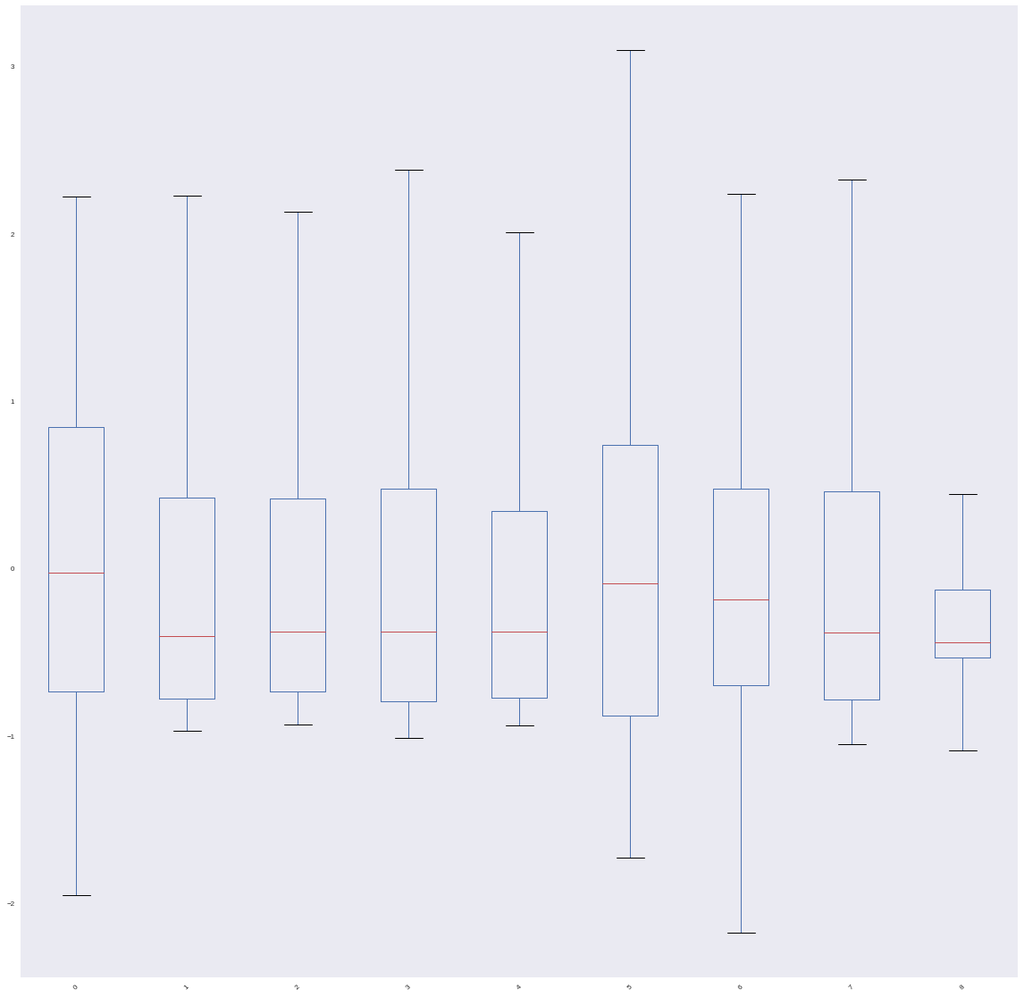

```python
total_df_reduced1.boxplot(grid=False, fontsize=8, rot=45, figsize=(20,20))
```

Visualize the correlation matrix between the 9 features

|  | 0 | 1 | 2 | 3 | 4 | 5 | 6 | 7 | 8 |
| --- | --- | --- | --- | --- | --- | --- | --- | --- | --- |
| 0 | 1.000000 | -0.465240 | -0.468009 | -0.481521 | -0.437971 | -0.490219 | 0.476421 | -0.458388 | 0.592930 |
| 1 | -0.465240 | 1.000000 | 0.998112 | 0.995809 | 0.995842 | 0.792257 | -0.509756 | 0.997385 | -0.329845 |
| 2 | -0.468009 | 0.998112 | 1.000000 | 0.990813 | 0.994056 | 0.769970 | -0.507899 | 0.992062 | -0.328574 |
| 3 | -0.481521 | 0.995809 | 0.990813 | 1.000000 | 0.984659 | 0.844741 | -0.573816 | 0.998644 | -0.384925 |
| 4 | -0.437971 | 0.995842 | 0.994056 | 0.984659 | 1.000000 | 0.742197 | -0.429265 | 0.990042 | -0.261516 |
| 5 | -0.490219 | 0.792257 | 0.769970 | 0.844741 | 0.742197 | 1.000000 | -0.845512 | 0.826474 | -0.638034 |
| 6 | 0.476421 | -0.509756 | -0.507899 | -0.573816 | -0.429265 | -0.845512 | 1.000000 | -0.538610 | 0.800497 |
| 7 | -0.458388 | 0.997385 | 0.992062 | 0.998644 | 0.990042 | 0.826474 | -0.538610 | 1.000000 | -0.341337 |
| 8 | 0.592930 | -0.329845 | -0.328574 | -0.384925 | -0.261516 | -0.638034 | 0.800497 | -0.341337 | 1.000000 |

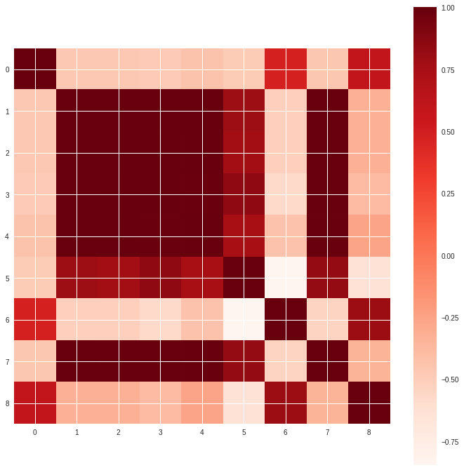

```python
display(total_df_reduced1.corr())
visualize_coeff_matrix(total_df_reduced1.corr())
```

Choose the best **K=6** features

```python
selector = SelectKBest(k=6)
selector.fit(total_df_normalized_zscore2, Y)
total_df_reduced2 = pd.DataFrame(selector.transform(total_df_normalized_zscore2))
print("Dataset after applying feature selection with the best 9 features")
display(total_df_reduced2)
```

```
Dataset after applying feature selection with the best 9 features
```

|  | 0 | 1 | 2 | 3 | 4 | 5 |
| --- | --- | --- | --- | --- | --- | --- |
| 0 | -0.808696 | -0.727621 | -0.839220 | -0.841382 | -0.870602 | 0.156038 |
| 1 | -0.796081 | -0.699073 | -0.836667 | -0.832214 | -0.855067 | 0.283547 |
| 2 | -0.810636 | -0.721277 | -0.849433 | -0.841382 | -0.875781 | 0.256926 |
| 3 | -0.817429 | -0.714933 | -0.867306 | -0.847494 | -0.870602 | 0.400405 |
| 4 | -0.812577 | -0.737137 | -0.839220 | -0.844438 | -0.868013 | 0.121116 |
| 5 | -0.825192 | -0.740309 | -0.862199 | -0.853607 | -0.886138 | 0.244069 |
| 6 | -0.446749 | -0.378706 | -0.420492 | -0.538826 | -0.448554 | -0.168482 |
| 7 | -0.501090 | -0.397737 | -0.522621 | -0.569387 | -0.552124 | 0.011522 |
| 8 | -0.507882 | -0.394565 | -0.530281 | -0.584668 | -0.559892 | 0.039329 |
| 9 | -0.412787 | -0.331126 | -0.400066 | -0.502153 | -0.427840 | -0.126668 |
| 10 | -0.867888 | -0.778372 | -0.923476 | -0.878056 | -0.922387 | 0.512593 |
| 11 | -0.356505 | -0.318438 | -0.300491 | -0.456311 | -0.326860 | -0.264250 |
| 12 | -0.804814 | -0.711761 | -0.846880 | -0.835270 | -0.860245 | 0.278391 |
| 13 | -0.402113 | -0.331126 | -0.382194 | -0.489928 | -0.409716 | -0.174334 |
| 14 | -0.479742 | -0.442145 | -0.435811 | -0.563275 | -0.464090 | -0.252963 |
| 15 | -0.806755 | -0.714933 | -0.849433 | -0.835270 | -0.865424 | 0.283683 |
| 16 | -0.812577 | -0.724449 | -0.846880 | -0.847494 | -0.873191 | 0.218878 |
| 17 | -0.500119 | -0.397737 | -0.512408 | -0.578556 | -0.541767 | -0.015515 |
| 18 | -0.800933 | -0.721277 | -0.826454 | -0.838326 | -0.857656 | 0.111215 |
| 19 | -0.816458 | -0.733965 | -0.851986 | -0.844438 | -0.875781 | 0.210508 |
| 20 | -0.823251 | -0.743481 | -0.854539 | -0.853607 | -0.880959 | 0.170403 |
| 21 | -0.270143 | -0.232796 | -0.206022 | -0.379908 | -0.231058 | -0.267454 |
| 22 | -0.828103 | -0.819608 | -0.816241 | -0.841382 | -0.849888 | -0.403110 |
| 23 | -0.409875 | -0.327954 | -0.402620 | -0.492984 | -0.430430 | -0.132317 |
| 24 | -0.345831 | -0.264515 | -0.326023 | -0.444086 | -0.352752 | -0.152731 |
| 25 | -0.366209 | -0.305751 | -0.331129 | -0.462423 | -0.357931 | -0.208766 |
| 26 | -0.820340 | -0.727621 | -0.864752 | -0.847494 | -0.880959 | 0.324135 |
| 27 | -0.801903 | -0.714933 | -0.834114 | -0.838326 | -0.860245 | 0.184620 |
| 28 | -0.439957 | -0.366018 | -0.430705 | -0.517433 | -0.458911 | -0.144150 |
| 29 | -0.281787 | -0.232796 | -0.223894 | -0.395188 | -0.249182 | -0.243444 |
| ... | ... | ... | ... | ... | ... | ... |
| 2280 | -0.194454 | -0.172528 | -0.175383 | -0.236270 | -0.199986 | -0.382962 |
| 2281 | -0.066366 | -0.036134 | -0.045169 | -0.120137 | -0.067935 | -0.375496 |
| 2282 | -0.858184 | -0.864015 | -0.839220 | -0.865831 | -0.873191 | -0.474379 |
| 2283 | -0.933873 | -0.908423 | -0.959221 | -0.917785 | -0.994886 | -0.412540 |
| 2284 | -0.934843 | -0.908423 | -0.961775 | -0.917785 | -0.997475 | -0.417122 |
| 2285 | -0.922228 | -0.892563 | -0.946455 | -0.911673 | -0.981940 | -0.351475 |
| 2286 | -0.934843 | -0.908423 | -0.961775 | -0.917785 | -0.997475 | -0.417122 |
| 2287 | -0.963954 | -0.936970 | -0.997520 | -0.939178 | -1.033725 | -0.473461 |
| 2288 | -0.876621 | -0.860843 | -0.882625 | -0.874999 | -0.917209 | -0.410938 |
| 2289 | -0.595215 | -0.565851 | -0.586451 | -0.627454 | -0.552124 | -0.281254 |
| 2290 | -0.752414 | -0.784716 | -0.706453 | -0.768035 | -0.738550 | -0.505497 |
| 2291 | -0.800933 | -0.813264 | -0.767730 | -0.819989 | -0.800692 | -0.469312 |
| 2292 | -0.674785 | -0.714933 | -0.611984 | -0.703857 | -0.642748 | -0.503323 |
| 2293 | -0.754355 | -0.768856 | -0.724325 | -0.768035 | -0.756675 | -0.507912 |
| 2294 | -0.803844 | -0.661010 | -0.908157 | -0.807765 | -0.826585 | 0.878944 |
| 2295 | -0.741740 | -0.746653 | -0.719219 | -0.755811 | -0.751497 | -0.463688 |
| 2296 | -0.961043 | -0.936970 | -0.989860 | -0.939178 | -1.025957 | -0.473461 |
| 2297 | -0.742711 | -0.768856 | -0.696240 | -0.764979 | -0.728193 | -0.455675 |
| 2298 | -0.930962 | -0.908423 | -0.949009 | -0.920841 | -0.984529 | -0.369153 |
| 2299 | -0.968806 | -0.936970 | -1.010286 | -0.939178 | -1.046671 | -0.473461 |
| 2300 | -0.779585 | -0.784716 | -0.762624 | -0.786372 | -0.795514 | -0.487165 |
| 2301 | -0.951339 | -0.924282 | -0.979647 | -0.933066 | -1.015600 | -0.360351 |
| 2302 | -0.952310 | -0.930626 | -0.971988 | -0.939178 | -1.007832 | -0.423698 |
| 2303 | -0.751444 | -0.733965 | -0.744751 | -0.768035 | -0.777389 | -0.350650 |
| 2304 | -0.797051 | -0.791060 | -0.783049 | -0.810821 | -0.816228 | -0.412004 |
| 2305 | -0.762118 | -0.756169 | -0.742198 | -0.783316 | -0.774800 | -0.401254 |
| 2306 | -0.751444 | -0.746653 | -0.739645 | -0.761923 | -0.772211 | -0.441456 |
| 2307 | -0.783466 | -0.778372 | -0.765177 | -0.801652 | -0.798103 | -0.409974 |
| 2308 | -0.749503 | -0.737137 | -0.734538 | -0.771091 | -0.767032 | -0.375761 |
| 2309 | -0.707778 | -0.708589 | -0.680920 | -0.731362 | -0.712658 | -0.431336 |

2310 rows × 6 columns

Visualize the reduced dataset of 6 features using boxplots

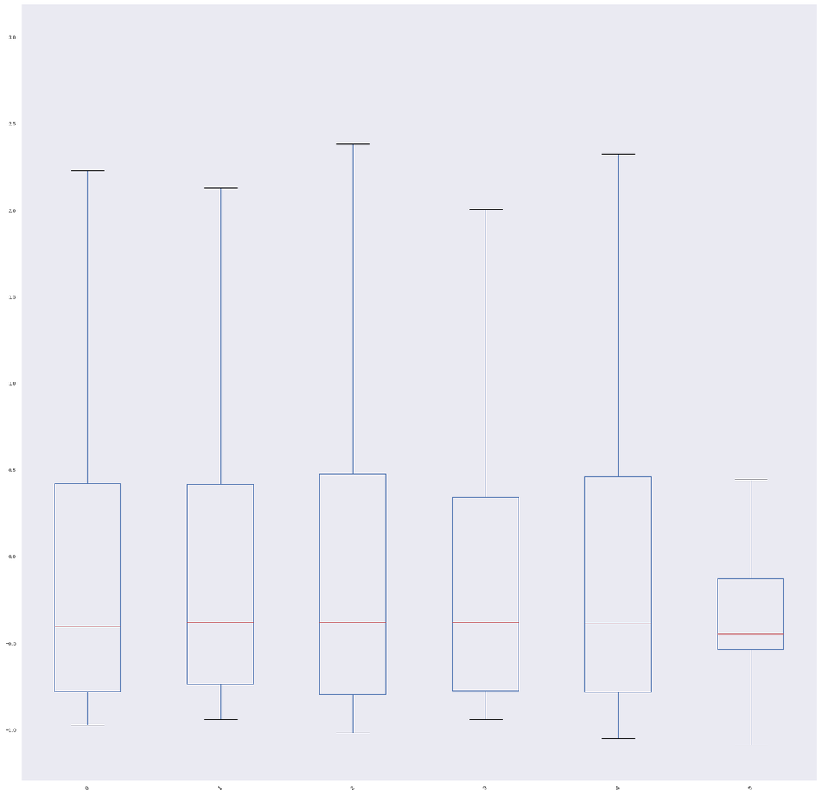

```python
total_df_reduced2.boxplot(grid=False, fontsize=8, rot=45, figsize=(20,20))
```

Visualize the correlation matrix between the 6 features

|  | 0 | 1 | 2 | 3 | 4 | 5 |
| --- | --- | --- | --- | --- | --- | --- |
| 0 | 1.000000 | 0.998112 | 0.995809 | 0.995842 | 0.997385 | -0.329845 |
| 1 | 0.998112 | 1.000000 | 0.990813 | 0.994056 | 0.992062 | -0.328574 |
| 2 | 0.995809 | 0.990813 | 1.000000 | 0.984659 | 0.998644 | -0.384925 |
| 3 | 0.995842 | 0.994056 | 0.984659 | 1.000000 | 0.990042 | -0.261516 |
| 4 | 0.997385 | 0.992062 | 0.998644 | 0.990042 | 1.000000 | -0.341337 |
| 5 | -0.329845 | -0.328574 | -0.384925 | -0.261516 | -0.341337 | 1.000000 |

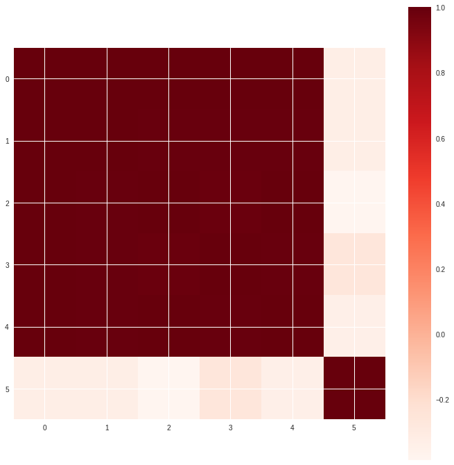

```python
display(total_df_reduced2.corr())
visualize_coeff_matrix(total_df_reduced2.corr())
```

**Conclusion:** Feature Selection on the other hand of PCA gives us features which are highly correlated with each other. So they are not the optimal dimensionality reduction as we can reduce the correlated attributes further more and get small number of features which is better for the running time.